# Global Sanitation Coverage Analysis - Enhanced

## 0.1 Student Details

- Name: Vishnu Vardhan kuncham venkatesulu
- Student ID: A00049469
- Course: MSC in Management(Strategy)
- Module: DATA ANALYTICS AND STORY TELLING

## 0.2 Introduction

Access to proper sanitation remains a critical global health and development issue. This project explores the global patterns of **sanitation access** from **2000 to 2022** using UNICEF-like data. Through dynamic visualizations, this report highlights trends, inequalities, economic drivers, and country-specific insights, aiding in **policy-making** and promoting **sanitation equity**.

# 1 Dataset Overview

The dataset, `unicef_indicator_2.csv`, contains: - **Country**: Country Name - **Year**: Year of Data Collection - **Indicator**: Sanitation indicator - **Value**: Access Percentage

```python
import pandas as pd

df = pd.read_csv("unicef_indicator_2.csv")
```

# 2 Global Sanitation Access Evolution

The Global Sanitation Access Evolution plot shows how sanitation access has progressed across selected countries from 2000 to 2022. While many countries have achieved steady improvements, some regions still lag behind. The trends highlight global inequalities and emphasize the need for stronger health and infrastructure policies.

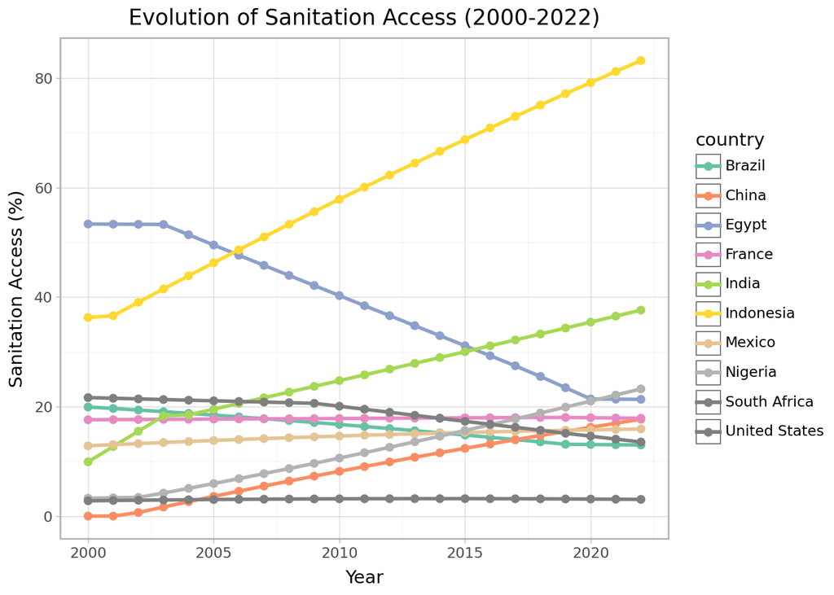

```python
from plotnine import *

countries_focus = ['Brazil', 'China', 'Egypt', 'France', 'India', 'Indonesia', 'Mexico', 'Nigeria', 'South Africa', 'United States']
data_focus = df[df['country'].isin(countries_focus)]

(
    ggplot(data_focus, aes(x='time_period', y='obs_value', color='country')) +
    geom_line(size=1.2) +
    geom_point(size=2) +
    labs(title='Evolution of Sanitation Access (2000-2022)',
         x='Year', y='Sanitation Access (%)') +
    scale_color_brewer(type='qual', palette='Set2') +
    theme_light()
)
```